# Visualisatie met Python

[figure not shown]

https://towardsdatascience.com/plotly-founder-on-what-data-science-is-and-where-its-going-46c5d6ec6a7d

# Korte inhoud

## - Functional P / Procedural P / OOP /

# Procedural programmeren/ Procedural programming

De organisatie van de logica in het script draait als een recept van boven naar beneden.

Met elke functie als apart *schakeltje* in de richting van de output.

# Functioneel programmeren/ Functional programming

Functional programming is de naam voor een programmeer-methode.  
Een paradigma dus.

Alles draait om de **puurheid** van de executie.  
**Functies** en **data** worden volledig gescheiden.

De **uitkomst** van een functie is zo dus afhankelijk van de **input.**

# Object georienteerd programmeren/ Object Oriented programming

Object Oriented programming of OOP (for short) is de naam voor een programmeer-methode.  
Een paradigma dus.

OOP is handig handig voor reproduceerbare code en zie je vaker bij development-werk

Je behandeld de data-behandelingen met objecten die je schrijft en aanroept.  
In de objecten zitten **attributes** en **methods**

Attributes:  
Parameters, aan te passen in the fly.

Methods:  
Functie-toebehoren van het object.

Natuurlijk blijven dit schakeltjes in de grote pipeline,  
Maar de parameters kunnen onderweg herbruikt en aangepast worden.  
Hierdoor is de output van een object.method afhenkelijk van beide:

- De input
- De parameters

# Matplotlib!

https://matplotlib.org/3.1.0/api/index.html

### We duiken niet te diep in Matplotlib!

Voor een inkijk een de basis van Matplotlib visualisatie.  
We focussen op de basis van pyplot...  
Hierin behandelen we de verschillende grafieken voor verschillende datatypes.

Dan behandelen we de object georienteerde manier van plotten.  
Deze geeft veel directere controle over de stijl en layout.

Binnen Matplotlib bestaan nog talloze visualisaties mocht je er in geinteresseerd zijn.  
Zelfs het vermogen tot interactieve plots.  
Voor meer informatie daarover kijk op:

https://matplotlib.org/3.1.1/gallery/index.html voorbeeldengallerij  
https://matplotlib.org/3.1.1/users/interactive.html Interactief documentatie

Hierna gaan we door naar Seaborn.  
Veel gemakkelijkere bruikbaarheid!

#### Dependencies importeren

```python
import pandas as pd
import numpy as np
import random
import matplotlib.pyplot as plt
```

#### Magic gebruiken: matplotlib inline

Hierdoor worden de visualisaties inline getoond.  
De visualisaties komen **in** het notebook.

```python
%matplotlib inline
```

### VoorbeeldData

```python
x = pd.Series(np.linspace(0, 10, 50), name = 'x')
y = pd.Series(np.sort(np.random.rand(50)), name = 'y')
z = pd.Series([random.randrange(-12, 21) for x in range(0,50)], name='z')
cat = pd.Series([random.randint(1, 3) for x in range(0, 50)], name='cat')
```

```python
Latssea = pd.DataFrame([x,y,z,cat]).T
```

# Visualisatie in MatplotLib: Procedural programming

## Pyplot

Pyplot is aan basis visualisatie-class  
voor procedural visualiseren.  
Hierin behandelen wij:

- Lijnplot
- Histogram
- Scatterplot
- Barchart
- Boxplot
- piechart

### Lijnplot

Ter introductie: de lijnplot.

Twee numerieke variabelen tegenover elkaar.

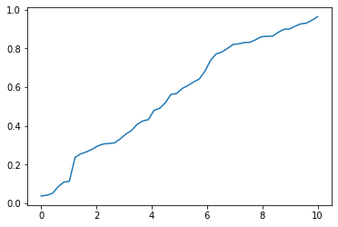

```python
plt.plot('x', 'y', data=Latssea)
```

## Beetje kaal...

Wie kan vertellen waar dit over gaat?

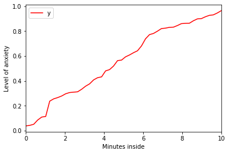

```python
Latssea.plot('x','y', color = 'r')
plt.xlabel("Minutes inside")
plt.ylabel("Level of anxiety")
```

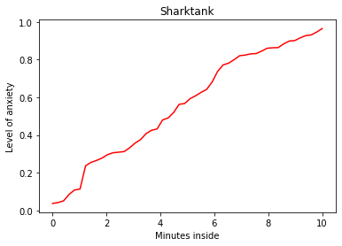

```python
plt.plot(Latssea['x'],Latssea['y'], 'r')
plt.xlabel("Minutes inside")
plt.ylabel("Level of anxiety")
plt.title("Sharktank")
```

## Opsomming:

- Matplotlib.pyplot.plot = standaard functie voor lijngrafiek
- Voor één output, roepen we verschillende functies aan van pyplot  
  **bijvoorbeeld:**

  ```
                                - Matplotlibpyplot.xlabel
                                - Matplotlibpyplot.ylabel
                                - Matplotlibpyplot.title
  ```

## Vraag:

```
  Welke drie verschillende manieren zijn er om data in een plot in te lezen?
  (zie ook het verschil in bovenstaande outputs)
```

# Subplot.

met subplot() kunnen we meerdere plots maken. Binnen een gedefinieerde tabel.

Subplot() neemt:

- nrows: Nummer van rijen
- ncols: Nummer van kollommen
- index: Plaats in de tabel

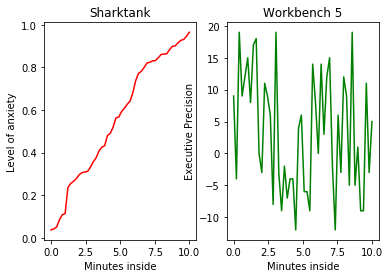

```python
plt.subplot(1,2,1)
plt.plot(x, y ,color= 'r')
plt.xlabel("Minutes inside")
plt.ylabel("Level of anxiety")
plt.title("Sharktank")
plt.subplot(1,2,2)
plt.plot(x, z, color='g',markevery=4)
plt.xlabel("Minutes inside")
plt.ylabel("Executive Precision")
plt.title("Workbench 5")
```

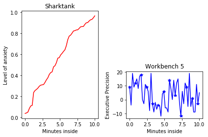

```python
plt.subplot(1,2,1)
plt.plot(x, y, 'r')
plt.xlabel("Minutes inside")
plt.ylabel("Level of anxiety")
plt.title("Sharktank")
plt.subplot(2,2,4)
plt.plot(x, z, 'b*-', markevery=4)
plt.xlabel("Minutes inside")
plt.ylabel("Executive Precision")
plt.title("Workbench 5")
plt.tight_layout()
```

# Figsize

De "figsize" parameter ven de "figure()" functie van "pyplot".  
Waar is deze voor? Wat zit er in?

```python
# Eigen code hier...
```

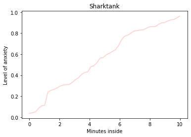

```python
plt.plot(Latssea['x'],Latssea['y'], 'r', alpha = 0.2)
plt.xlabel("Minutes inside")
plt.ylabel("Level of anxiety")
plt.title("Sharktank")
```

# *args & **kwargs

Nifty addition, si? transparansii...

*args en **kwargs geven de gebruiker van de functie  
de mogelijkheid om vrij argumenten toe te voegen aan een funtie.

*args staat losse argumenten toe, zoals strings of waardes.

**kwargs geeft een dict mogelijkheid.

Voor meer informatie over args en kwargs kijk hier:  
https://www.geeksforgeeks.org/args-kwargs-python/

# Actie:

Maak je bekent met de waarden van subplot  
In een groter canvas  
Maak de visualisatie ...'your own'...  
Met de kleur en marker **kwarg mogelijkheden van plot()

### Kleuren en Markers

Bekijk de standaard Matplotlib kleur en marker specificaties.

```
Welke kleurnotaties neemt matplotlib?
```

https://matplotlib.org/api/colors_api.html#module-matplotlib.colors

```
En hieronder een oversicht van de verschillende markernotaties
```

https://matplotlib.org/api/markers_api.html

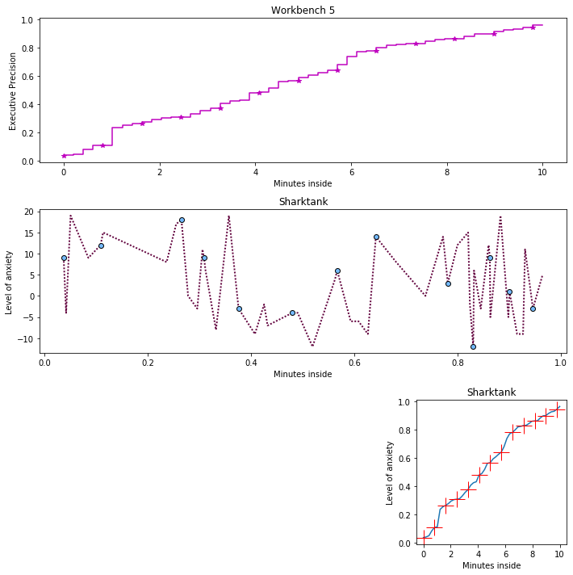

```python
plt.figure(figsize=(10,10))
plt.subplot(3,3,9)
plt.plot(x, y, 'tab:blue', marker='+', markersize=20, markeredgecolor='red', markevery=4)
plt.xlabel("Minutes inside")
plt.ylabel("Level of anxiety")
plt.title("Sharktank")
plt.subplot(3,1,2)
plt.plot(y, z, color='#640640', linewidth = 2, alpha=1, dashes=[1,1], marker='o', mfc = 'xkcd:sky blue', mec='xkcd:Black', markevery=4)
plt.xlabel("Minutes inside")
plt.ylabel("Level of anxiety")
plt.title("Sharktank")
plt.subplot(3,1,1)
plt.plot(x, y, 'm*-', markevery=4,  drawstyle="steps")
plt.xlabel("Minutes inside")
plt.ylabel("Executive Precision")
plt.title("Workbench 5")
plt.tight_layout()
```

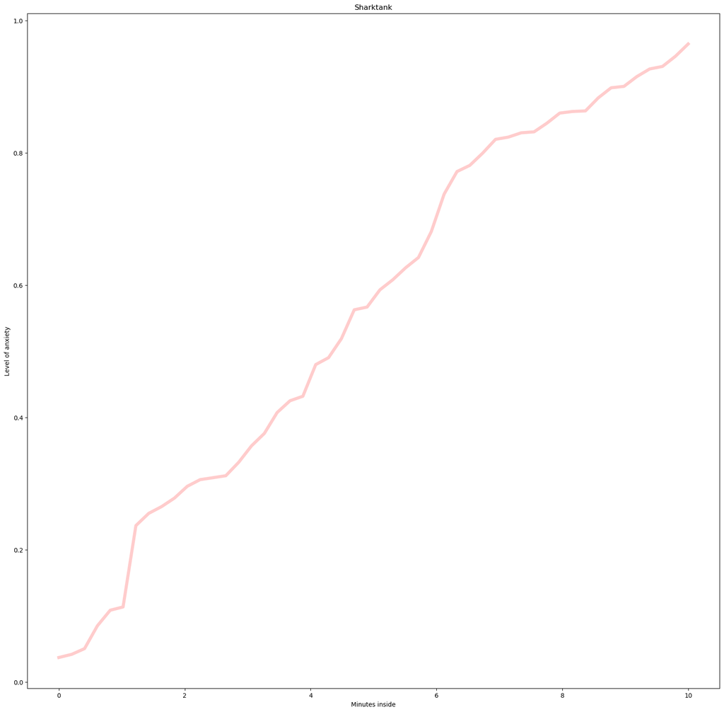

```python
plt.figure(figsize=(20,20), dpi=100)
plt.plot(Latssea['x'],Latssea['y'],
         alpha = 0.2,
         linewidth= 5,
         animated= True,
         aa= True,
         clip_on= True,
         c= 'red',
         dash_capstyle= 'round')
plt.xlabel("Minutes inside")
plt.ylabel("Level of anxiety")
plt.title("Sharktank")
```

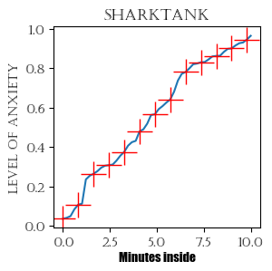

```python
hfont = {'fontname':'Impact'}
plt.rcParams["font.family"] = "Castellar"
plt.figure(figsize=(10,10), dpi=100)
plt.subplot(3,3,9)
plt.plot(x, y, 'tab:blue', marker='+', markersize=20, markeredgecolor='red', markevery=4)
plt.xlabel("Minutes inside", **hfont)
plt.ylabel("Level of anxiety")
plt.title("Sharktank")
# plt.text(-1,-1, "hahaha", fontsize=26)
```

# De kracht van een open source community

https://matplotlib.org/3.1.1/api/_as_gen/matplotlib.pyplot.text.html  
http://jonathansoma.com/lede/data-studio/matplotlib/list-all-fonts-available-in-matplotlib-plus-samples/  
https://matplotlib.org/tutorials/introductory/customizing.html

```python
import matplotlib.font_manager
from IPython.core.display import HTML

def make_html(fontname):
    return "<p>{font}: <span style='font-family:{font}; font-size: 24px;'>{font}</p>".format(font=fontname)

code = "\n".join([make_html(font) for font in sorted(set([f.name for f in matplotlib.font_manager.fontManager.ttflist]))])

HTML("<div style='column-count: 2;'>{}</div>".format(code))
```

Agency FB: Agency FB

Algerian: Algerian

Arial: Arial

Arial Nova: Arial Nova

Arial Rounded MT Bold: Arial Rounded MT Bold

Bahnschrift: Bahnschrift

Baskerville Old Face: Baskerville Old Face

Bauhaus 93: Bauhaus 93

Bell MT: Bell MT

Berlin Sans FB: Berlin Sans FB

Berlin Sans FB Demi: Berlin Sans FB Demi

Bernard MT Condensed: Bernard MT Condensed

Blackadder ITC: Blackadder ITC

Bodoni MT: Bodoni MT

Book Antiqua: Book Antiqua

Bookman Old Style: Bookman Old Style

Bookshelf Symbol 7: Bookshelf Symbol 7

Bradley Hand ITC: Bradley Hand ITC

Britannic Bold: Britannic Bold

Broadway: Broadway

Brush Script MT: Brush Script MT

Calibri: Calibri

Californian FB: Californian FB

Calisto MT: Calisto MT

Cambria: Cambria

Candara: Candara

Castellar: Castellar

Centaur: Centaur

Century: Century

Century Gothic: Century Gothic

Century Schoolbook: Century Schoolbook

Chiller: Chiller

Colonna MT: Colonna MT

Comic Sans MS: Comic Sans MS

Consolas: Consolas

Constantia: Constantia

Cooper Black: Cooper Black

Copperplate Gothic Bold: Copperplate Gothic Bold

Copperplate Gothic Light: Copperplate Gothic Light

Corbel: Corbel

Courier New: Courier New

Curlz MT: Curlz MT

DejaVu Sans: DejaVu Sans

DejaVu Sans Display: DejaVu Sans Display

DejaVu Sans Mono: DejaVu Sans Mono

DejaVu Serif: DejaVu Serif

DejaVu Serif Display: DejaVu Serif Display

Dubai: Dubai

Ebrima: Ebrima

Edwardian Script ITC: Edwardian Script ITC

Elephant: Elephant

Engravers MT: Engravers MT

Eras Bold ITC: Eras Bold ITC

Eras Demi ITC: Eras Demi ITC

Eras Light ITC: Eras Light ITC

Eras Medium ITC: Eras Medium ITC

Felix Titling: Felix Titling

Footlight MT Light: Footlight MT Light

Forte: Forte

Franklin Gothic Book: Franklin Gothic Book

Franklin Gothic Demi: Franklin Gothic Demi

Franklin Gothic Demi Cond: Franklin Gothic Demi Cond

Franklin Gothic Heavy: Franklin Gothic Heavy

Franklin Gothic Medium: Franklin Gothic Medium

Franklin Gothic Medium Cond: Franklin Gothic Medium Cond

Freestyle Script: Freestyle Script

French Script MT: French Script MT

Gabriola: Gabriola

Gadugi: Gadugi

Garamond: Garamond

Georgia: Georgia

Georgia Pro: Georgia Pro

Gigi: Gigi

Gill Sans MT: Gill Sans MT

Gill Sans MT Condensed: Gill Sans MT Condensed

Gill Sans MT Ext Condensed Bold: Gill Sans MT Ext Condensed Bold

Gill Sans Nova: Gill Sans Nova

Gill Sans Ultra Bold: Gill Sans Ultra Bold

Gill Sans Ultra Bold Condensed: Gill Sans Ultra Bold Condensed

Gloucester MT Extra Condensed: Gloucester MT Extra Condensed

Goudy Old Style: Goudy Old Style

Goudy Stout: Goudy Stout

Haettenschweiler: Haettenschweiler

Harlow Solid Italic: Harlow Solid Italic

Harrington: Harrington

High Tower Text: High Tower Text

HoloLens MDL2 Assets: HoloLens MDL2 Assets

Impact: Impact

Imprint MT Shadow: Imprint MT Shadow

Informal Roman: Informal Roman

Ink Free: Ink Free

Javanese Text: Javanese Text

Jokerman: Jokerman

Juice ITC: Juice ITC

Kristen ITC: Kristen ITC

Kunstler Script: Kunstler Script

Leelawadee: Leelawadee

Leelawadee UI: Leelawadee UI

Lucida Bright: Lucida Bright

Lucida Calligraphy: Lucida Calligraphy

Lucida Console: Lucida Console

Lucida Fax: Lucida Fax

Lucida Handwriting: Lucida Handwriting

Lucida Sans: Lucida Sans

Lucida Sans Typewriter: Lucida Sans Typewriter

Lucida Sans Unicode: Lucida Sans Unicode

MS Gothic: MS Gothic

MS Outlook: MS Outlook

MS Reference Sans Serif: MS Reference Sans Serif

MS Reference Specialty: MS Reference Specialty

MT Extra: MT Extra

MV Boli: MV Boli

Magneto: Magneto

Maiandra GD: Maiandra GD

Malgun Gothic: Malgun Gothic

Marlett: Marlett

Matura MT Script Capitals: Matura MT Script Capitals

Microsoft Himalaya: Microsoft Himalaya

Microsoft JhengHei: Microsoft JhengHei

Microsoft New Tai Lue: Microsoft New Tai Lue

Microsoft PhagsPa: Microsoft PhagsPa

Microsoft Sans Serif: Microsoft Sans Serif

Microsoft Tai Le: Microsoft Tai Le

Microsoft Uighur: Microsoft Uighur

Microsoft YaHei: Microsoft YaHei

Microsoft Yi Baiti: Microsoft Yi Baiti

MingLiU-ExtB: MingLiU-ExtB

Mistral: Mistral

Modern No. 20: Modern No. 20

Mongolian Baiti: Mongolian Baiti

Monotype Corsiva: Monotype Corsiva

Myanmar Text: Myanmar Text

Neue Haas Grotesk Text Pro: Neue Haas Grotesk Text Pro

Niagara Engraved: Niagara Engraved

Niagara Solid: Niagara Solid

Nirmala UI: Nirmala UI

OCR A Extended: OCR A Extended

Old English Text MT: Old English Text MT

Onyx: Onyx

Palace Script MT: Palace Script MT

Palatino Linotype: Palatino Linotype

Papyrus: Papyrus

Parchment: Parchment

Perpetua: Perpetua

Perpetua Titling MT: Perpetua Titling MT

Playbill: Playbill

Poor Richard: Poor Richard

Pristina: Pristina

Rage Italic: Rage Italic

Ravie: Ravie

Rockwell: Rockwell

Rockwell Condensed: Rockwell Condensed

Rockwell Extra Bold: Rockwell Extra Bold

Rockwell Nova: Rockwell Nova

STIXGeneral: STIXGeneral

STIXNonUnicode: STIXNonUnicode

STIXSizeFiveSym: STIXSizeFiveSym

STIXSizeFourSym: STIXSizeFourSym

STIXSizeOneSym: STIXSizeOneSym

STIXSizeThreeSym: STIXSizeThreeSym

STIXSizeTwoSym: STIXSizeTwoSym

Script MT Bold: Script MT Bold

Segoe MDL2 Assets: Segoe MDL2 Assets

Segoe Print: Segoe Print

Segoe Script: Segoe Script

Segoe UI: Segoe UI

Segoe UI Emoji: Segoe UI Emoji

Segoe UI Historic: Segoe UI Historic

Segoe UI Symbol: Segoe UI Symbol

Showcard Gothic: Showcard Gothic

SimSun: SimSun

SimSun-ExtB: SimSun-ExtB

Sitka Small: Sitka Small

Snap ITC: Snap ITC

Stencil: Stencil

Sylfaen: Sylfaen

Symbol: Symbol

Tahoma: Tahoma

Tempus Sans ITC: Tempus Sans ITC

Times New Roman: Times New Roman

Trebuchet MS: Trebuchet MS

Tw Cen MT: Tw Cen MT

Tw Cen MT Condensed: Tw Cen MT Condensed

Tw Cen MT Condensed Extra Bold: Tw Cen MT Condensed Extra Bold

Verdana: Verdana

Verdana Pro: Verdana Pro

Viner Hand ITC: Viner Hand ITC

Vivaldi: Vivaldi

Vladimir Script: Vladimir Script

Webdings: Webdings

Wide Latin: Wide Latin

Wingdings: Wingdings

Wingdings 2: Wingdings 2

Wingdings 3: Wingdings 3

Yu Gothic: Yu Gothic

cmb10: cmb10

cmex10: cmex10

cmmi10: cmmi10

cmr10: cmr10

cmss10: cmss10

cmsy10: cmsy10

cmtt10: cmtt10

```python
plt.rcParams["font.family"] = "Trebuchet MS"
plt.rcParams["font.size"] = 13
hfont = dict(fontname = 'Impact',
         weight = 'bold',
         size   = 22,
         color = 'red')
cast = {'fontname':'Castellar'}
```

```python
plt.rcParams.keys()
```

[output not shown]

[output cut: 289 more lines]

[output not shown]

# voor meer over stijl...

https://matplotlib.org/3.2.0/tutorials/introductory/customizing.html

# Object Oriented visualiseren:

Maak een object door het aan te roepen en te declareren.  
Dan methodes en attributes gebruiken.

- Plaatsing van meerdere visualisaties (op Axes) in 1 canvas (figure).
- Overall controle door plots & canvas als afzonderlijke objecten te behandelen.

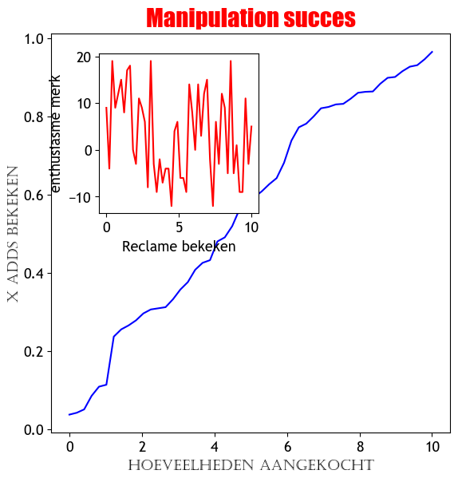

```python
fig = plt.figure(figsize=(5,5), dpi=100)

axes = fig.add_axes([0, 0, 1, 1]) # links, onder, wijdte, hoogte (range 0 tot 1)

axes.plot(x, y, 'b')
axes.set_xlabel('Hoeveelheden aangekocht', **cast) # Notice the use of set_ to begin methods
axes.set_ylabel('x adds bekeken', **cast)
axes.set_title('Manipulation succes', **hfont)

axes1 = fig.add_axes([0.12, 0.55, 0.4, 0.4]) # links, onder, wijdte, hoogte (range 0 tot 1)

axes1.plot(x, z, 'r')
axes1.set_xlabel('Reclame bekeken') # Notice the use of set_ to begin methods
axes1.set_ylabel('enthusiasme merk')
```

```python
axes.plot(x, y, 'g')
```

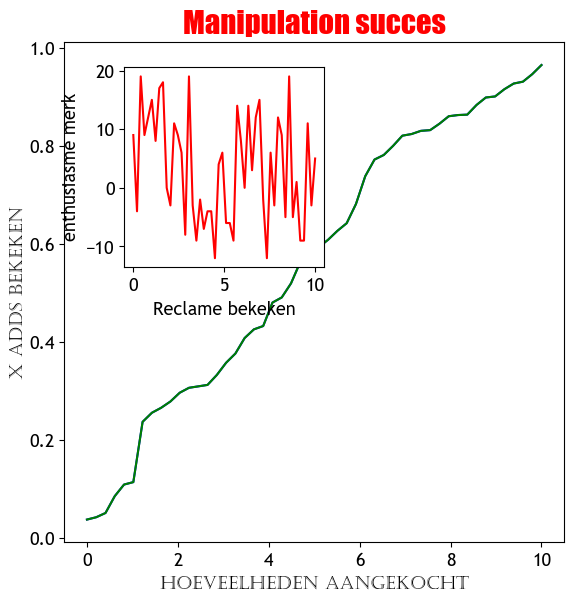

```python
fig
```

### De flexibiliteit van werken met objecten.

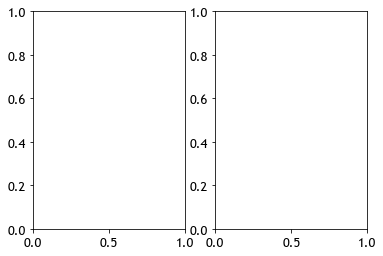

```python
fig, axes = plt.subplots(nrows=1, ncols=2)
```

[output not shown]

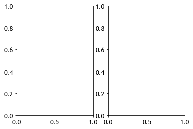

```python
plt.subplots(nrows=1, ncols=2)
```

Voor meer over tupple unpacking en multiple assignment:  
https://treyhunner.com/2018/03/tuple-unpacking-improves-python-code-readability/

### Wat is axes nu?

```python
axes
```

```
array([<matplotlib.axes._subplots.AxesSubplot object at 0x0000024B83C4B5C8>,
      dtype=object)
```

```python
for ax in axes:
    ax.plot(x, y, 'b')
    ax.set_xlabel('x')
    ax.set_ylabel('y')
    ax.set_title('title')
```

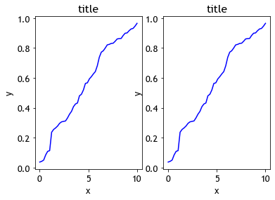

```python
fig
```

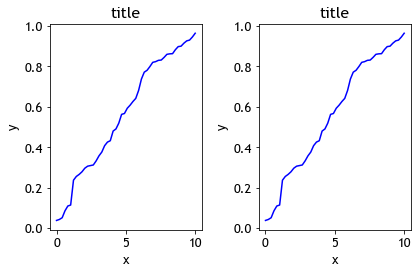

```python
fig.tight_layout()
fig
```

## Iteration

Op deze manier kunnen we met een forloop  
Door allerlei waardes van data loopen  
Middels de index  
En gemakkelijk, automatisch zaken visualiseren

```
array([[<matplotlib.axes._subplots.AxesSubplot object at 0x0000024B8361F808>,
      dtype=object)
```

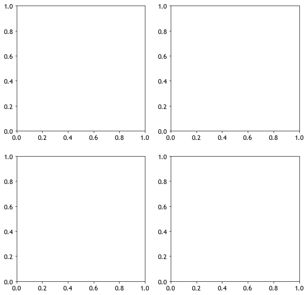

```python
fig, axes = plt.subplots(nrows = 2, ncols = 2, figsize=(10,10)) #sharex=True, sharey=True
axes
```

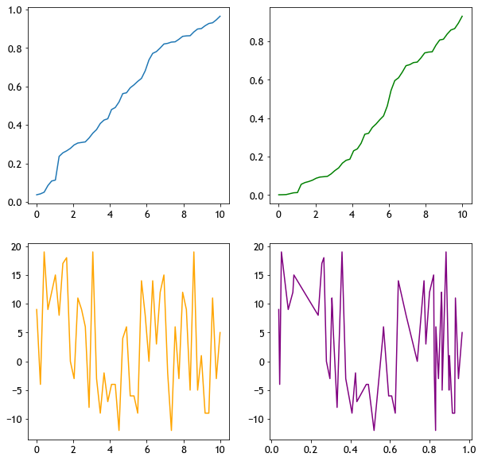

```python
axes[0,0].plot(x,y)
axes[1,0].plot(x,z, 'orange')
axes[0,1].plot(x,y**2, 'green')
axes[1,1].plot(y,z, 'purple')
fig
```

## Actie:

Kijk nog eens naar de fantastische grafiek  
over Manipulatie-succes door adds.

- Speel met de waardes van de axes.

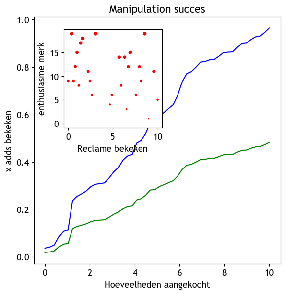

```python
fig = plt.figure(figsize=(5,5), dpi=100)

axes = fig.add_axes([0, 0, 1, 1]) # links, onder, wijdte, hoogte (range 0 tot 1)
axes1 = fig.add_axes([0.12, 0.55, 0.4, 0.4]) # links, onder, wijdte, hoogte (range 0 tot 1)

ax1 = axes.plot(x, y,color= 'b')
ax2 = axes.plot(x, (y/2),color= 'g')
axes.set_xlabel('Hoeveelheden aangekocht')
axes.set_ylabel('x adds bekeken')
axes.set_title('Manipulation succes')


axes1.scatter('x', 'z', data=Latssea,color= 'r', s='z')
axes1.set_xlabel('Reclame bekeken')
axes1.set_ylabel('enthusiasme merk')
```

# Actie:

Kijk nog eens naar de fantastische grafiek  
over Manipulatie-succes door adds.

- Speel met de waardes van de axes.
- Kies voor jou passende styling.

  Ga dan naar de documentatiepagina van matplotlib.pyplot.legend()
- probeer een legenda toe te voegen aan deze plot.

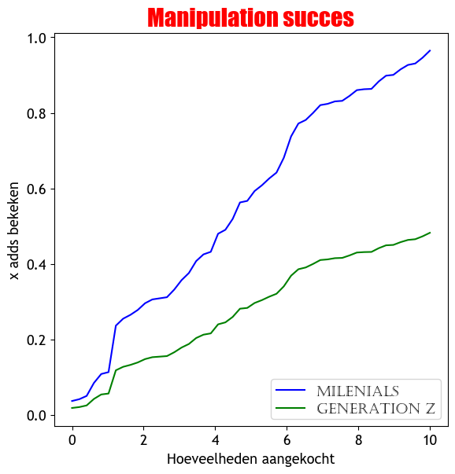

```python
fig = plt.figure(figsize=(5,5), dpi=100)

axes = fig.add_axes([0, 0, 1, 1])


ax1 = axes.plot(x, y, 'b', label= "Milenials")
ax2 = axes.plot(x, (y)/2, 'g',  label = "Generation Z")
# axes.set_ylim([0, 10])
# axes.set_xlim([1, 50])
axes.set_xlabel('Hoeveelheden aangekocht') # Notice the use of set_ to begin methods
axes.set_ylabel('x adds bekeken')
axes.set_title('Manipulation succes', **hfont)

axes.legend(loc=4, prop = {'family':"Castellar", 'size':13})
```

# Histogram

Handig voor Distributie-indicatie.

Ook hier kunnen we spelen met:

- bins
- Facecolor
- linekleur
- aplha
- etc etc etc

Bekijk en speel met de parameters van *plt.hist*  
https://matplotlib.org/3.1.1/api/_as_gen/matplotlib.patches.Patch.html#matplotlib.patches.Patch

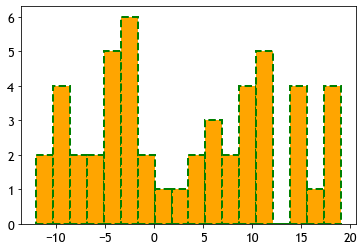

```python
plt.hist(z, bins=18, ec="green", fc="orange", lw=2, ls="--")
```

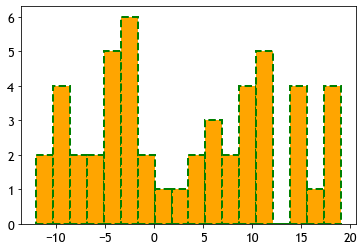

```python
hist = {"ec":"green", "fc":"orange", "lw":2, "ls":"--"}
histstyle = dict(ec="green", fc="orange", lw=2, ls="--")
plt.hist(z, bins=18,**hist)
```

## Piechart

Bruikbaar voor hoeveelheid voorkomens per categorie.

Gebruik de help functies:  
Hoe heeft Piechart graag de koffie?

```python
plt.pie?
```

### x: array-like, the wedge sizes!

Cat was onze categorische attribuut.  
Maar de voorkomens per cat zijn nu nog niet geaggregeerd tot één array.

### Actie:

Aggregeer de voorkomend per categorie 'cat', tot één Array.

Zorg dat je ook de juiste categorie-namen in dezelfde volgorde in een array hebt.

```python
nunique_cats = np.unique(cat, return_counts=True)[1]
nunique_cats
```

```
array([16, 20, 14], dtype=int64)
```

```python
np.unique(cat, return_counts=True)
```

```
(array([1, 2, 3], dtype=int64), array([16, 20, 14], dtype=int64))
```

```
 [Text(-0.5894094953465411, -0.928760704807937, '1'),
 [Text(-0.3214960883708406, -0.5065967480770565, '32.0%'),
```

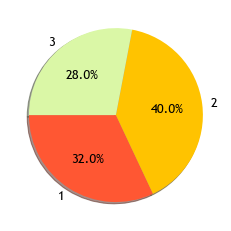

```python
colors = ['#FF5733', '#FFC300', '#DAF7A6']
labels = np.unique(cat, return_counts=False)

plt.pie(nunique_cats, labels=labels,
autopct='%1.1f%%', shadow=True, startangle=180, colors = colors, )
```

## Boxplot

De boxplot. Een heerlijke visuale indicatie van de verdeling & dichtheid van onze datapunten.

van UitschietersMinimum  
tot uitschieterMaximum:  
langs minimum (niet-uitschieter),  
de 3 kwartielen  
en het maximum(niet uitschieter)

```
{'whiskers': [<matplotlib.lines.Line2D at 0x24b8462cf48>,
 'caps': [<matplotlib.lines.Line2D at 0x24b84633e08>,
 'boxes': [<matplotlib.lines.Line2D at 0x24b8462c888>,
 'medians': [<matplotlib.lines.Line2D at 0x24b84633fc8>,
 'fliers': [<matplotlib.lines.Line2D at 0x24b84638f08>,
 'means': []}
```

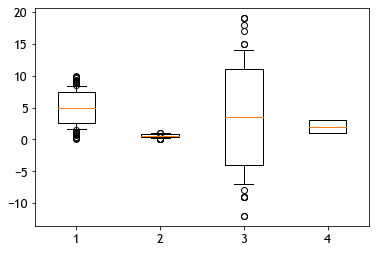

```python
plt.boxplot([Latssea['x'], Latssea['y'], Latssea['z'], Latssea['cat']], vert=True, whis = 0.2)
```

## Scatterplot:

A dot for evey datapoint.  
Geeft distributie weer van quantitatieve variabelen.

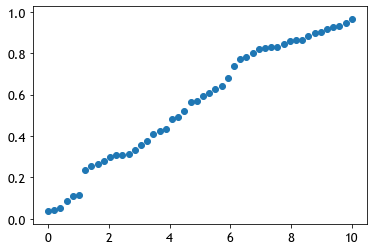

```python
plt.scatter(Latssea['x'], Latssea['y'])
```

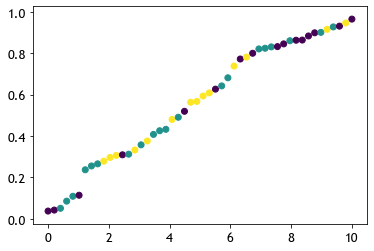

```python
plt.scatter(Latssea['x'], Latssea['y'], c=cat)
```

https://matplotlib.org/tutorials/colors/colormaps.html

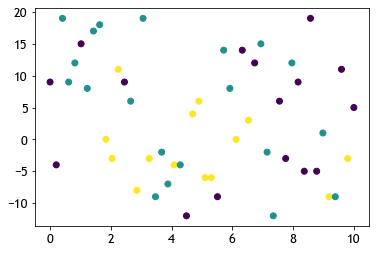

```python
plt.scatter(Latssea['x'], Latssea['z'], c=cat)
```

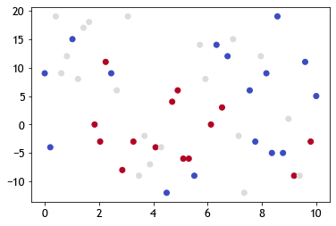

```python
plt.scatter(Latssea['x'], Latssea['z'], c=cat, cmap='coolwarm')
```

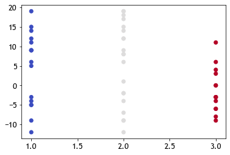

```python
plt.scatter(Latssea['cat'], Latssea['z'], c=cat, cmap='coolwarm')
```

# Opdracht:

Geef x weer gegroepeerd per categorie 'cat'.  
In 1 boxplot-plot.

Onthoud: Boxplot geeft de distributie weer per attribuut.  
Hoe aggregeren we de data passend?

```python
X_divby_Cat = [Latssea[Latssea['cat'] == 1]['x'],
Latssea[Latssea['cat'] == 2]['x'],
Latssea[Latssea['cat'] == 3]['x']]
```

```
{'whiskers': [<matplotlib.lines.Line2D at 0x24b848d23c8>,
 'caps': [<matplotlib.lines.Line2D at 0x24b848d2c88>,
 'boxes': [<matplotlib.lines.Line2D at 0x24b848ce9c8>,
 'medians': [<matplotlib.lines.Line2D at 0x24b848d6c08>,
 'fliers': [<matplotlib.lines.Line2D at 0x24b848daa88>,
 'means': []}
```

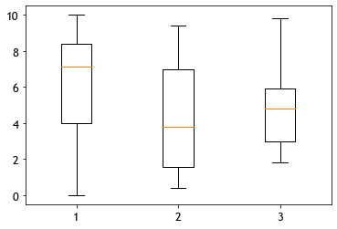

```python
plt.boxplot(X_divby_Cat, vert=True)
```

# OOP vormgeving.

Ook deze vizzes passen in onze OOP-methode

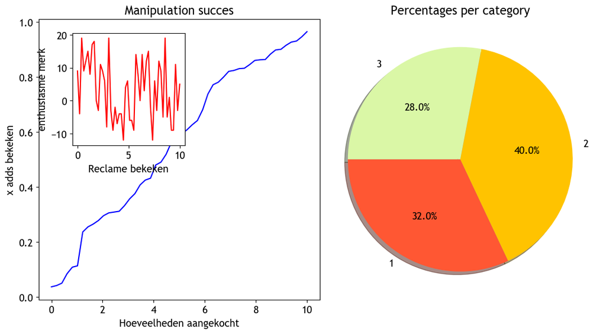

```python
fig = plt.figure(figsize=(5,5), dpi=100)

axes = fig.add_axes([0, 0, 1, 1]) # links, onder, wijdte, hoogte (range 0 tot 1)

axes.plot(x, y, 'b')
axes.set_xlabel('Hoeveelheden aangekocht') # Notice the use of set_ to begin methods
axes.set_ylabel('x adds bekeken')
axes.set_title('Manipulation succes')

axes1 = fig.add_axes([0.12, 0.55, 0.4, 0.4]) # links, onder, wijdte, hoogte (range 0 tot 1)

axes1.plot(x, z, 'r')
axes1.set_xlabel('Reclame bekeken') # Notice the use of set_ to begin methods
axes1.set_ylabel('enthusiasme merk')

axes2 = fig.add_axes([1, 0, 1, 1])

axes2.pie(nunique_cats, labels=labels,
autopct='%1.1f%%', shadow=True, startangle=180, colors = colors)
axes2.set_title("Percentages per category")
```

# Actie:

Importeer de Titanic Dataset.  
En probeer botvier je nieuwe matplotlib-skills

**Aanpak:**  
Maak eerst een overzicht met wat subplots in een figure.

Probeer dan object georienteerd een goede positie te vinden voor Axes. En geef een mooi overzicht over de Titanic-dataset.

*vergeet geen:* Labels, Titels, Ticks etc. kleurstelling

```
  ...Hoe lees je dat ook alweer in?
```

```python
Data = pd.read_csv('data/fulltitanic.csv')
```

```python
Data.info()
```

```
<class 'pandas.core.frame.DataFrame'>
RangeIndex: 1309 entries, 0 to 1308
Data columns (total 23 columns):
Unnamed: 0       1309 non-null int64
Age              1046 non-null float64
Cabin            295 non-null object
Embarked         1307 non-null object
Fare             1308 non-null float64
Name             1309 non-null object
Parch            1309 non-null int64
PassengerId      1309 non-null int64
Pclass           1309 non-null int64
Sex              1309 non-null object
SibSp            1309 non-null int64
Survived         891 non-null float64
Ticket           1309 non-null object
Title            1309 non-null object
Age_mean         1309 non-null float64
Fare_fill        1309 non-null float64
Embarked_fill    1309 non-null object
Age_fill         1309 non-null float64
Cabin_fill       1309 non-null object
FamilySize       1309 non-null int64
Family_Single    1309 non-null int64
Family_Small     1309 non-null int64
Family_Large     1309 non-null int64
dtypes: float64(6), int64(9), object(8)
memory usage: 235.3+ KB
```

```python
TVis = Data[Data['Survived'].notnull()]
```

# Welke data ga ik plotten?

### Lekker aggregeren...

```python
TVis_fem = TVis[TVis['Sex']=='female']
TVis_mal = TVis[TVis['Sex']=='male']

TVis_fem_perClass_Survived = TVis_fem[TVis_fem['Survived'] == 1].groupby('Pclass').count()
TVis_fem_perClass_notSurvived = TVis_fem[TVis_fem['Survived'] == 0].groupby('Pclass').count()

TVis_mal_perClass_Survived = TVis_mal[TVis_mal['Survived'] == 1].groupby('Pclass').count()
TVis_mal_perClass_notSurvived = TVis_mal[TVis_mal['Survived'] == 0].groupby('Pclass').count()

TVis_fem_class1 = TVis_fem[TVis_fem['Pclass']==1]
TVis_fem_class2 = TVis_fem[TVis_fem['Pclass']==2]
TVis_fem_class3 = TVis_fem[TVis_fem['Pclass']==3]
TVis_mal_class1 = TVis_mal[TVis_mal['Pclass']==1]
TVis_mal_class2 = TVis_mal[TVis_mal['Pclass']==2]
TVis_mal_class3 = TVis_mal[TVis_mal['Pclass']==3]

TVis_fem_class1_Count_in_Survived = np.unique(TVis_fem_class1['Survived'], return_counts=True)[1]
TVis_fem_class1_Count_in_Survived_labels = np.unique(TVis_fem_class1['Survived'], return_counts=True)[0]
TVis_fem_class2_Count_in_Survived = np.unique(TVis_fem_class2['Survived'], return_counts=True)[1]
TVis_fem_class2_Count_in_Survived_labels = np.unique(TVis_fem_class2['Survived'], return_counts=True)[0]
TVis_fem_class3_Count_in_Survived = np.unique(TVis_fem_class3['Survived'], return_counts=True)[1]
TVis_fem_class3_Count_in_Survived_labels = np.unique(TVis_fem_class3['Survived'], return_counts=True)[0]

TVis_mal_class1_Count_in_Survived = np.unique(TVis_mal_class1['Survived'], return_counts=True)[1]
TVis_mal_class1_Count_in_Survived_labels = np.unique(TVis_mal_class1['Survived'], return_counts=True)[0]
TVis_mal_class2_Count_in_Survived = np.unique(TVis_mal_class2['Survived'], return_counts=True)[1]
TVis_mal_class2_Count_in_Survived_labels = np.unique(TVis_mal_class2['Survived'], return_counts=True)[0]
TVis_mal_class3_Count_in_Survived = np.unique(TVis_mal_class3['Survived'], return_counts=True)[1]
TVis_mal_class3_Count_in_Survived_labels = np.unique(TVis_mal_class3['Survived'], return_counts=True)[0]

TVis_fem_Count_in_Pclass = np.unique(TVis_fem['Pclass'], return_counts=True)[1]
TVis_fem_Count_in_Pclass_labels = np.unique(TVis_fem['Pclass'], return_counts=True)[0]

TVis_mal_Count_in_Pclass = np.unique(TVis_mal['Pclass'], return_counts=True)[1]
TVis_mal_Count_in_Pclass_labels = np.unique(TVis_mal['Pclass'], return_counts=True)[0]
```

```python
TVis_mal_perClass_notSurvived
```

| Pclass | Unnamed: 0 | Age | Cabin | Embarked | Fare | Name | Parch | PassengerId | Sex | SibSp | ... | Title | Age_mean | Fare_fill | Embarked_fill | Age_fill | Cabin_fill | FamilySize | Family_Single | Family_Small | Family_Large |
| --- | --- | --- | --- | --- | --- | --- | --- | --- | --- | --- | --- | --- | --- | --- | --- | --- | --- | --- | --- | --- | --- |
| 1 | 77 | 61 | 56 | 77 | 77 | 77 | 77 | 77 | 77 | 77 | ... | 77 | 77 | 77 | 77 | 77 | 77 | 77 | 77 | 77 | 77 |
| 2 | 91 | 84 | 2 | 91 | 91 | 91 | 91 | 91 | 91 | 91 | ... | 91 | 91 | 91 | 91 | 91 | 91 | 91 | 91 | 91 | 91 |
| 3 | 300 | 215 | 4 | 300 | 300 | 300 | 300 | 300 | 300 | 300 | ... | 300 | 300 | 300 | 300 | 300 | 300 | 300 | 300 | 300 | 300 |

3 rows × 22 columns

# Dashboard.

### Even snel bouwen...

[figure not shown]

```python
fig = plt.figure(figsize=(10,10), dpi=100)

axes = fig.add_axes([0, 0.6, 0.45, 0.35]) # links, onder, wijdte, hoogte (range 0 tot 1)

axes.bar(np.array(TVis_fem_perClass_notSurvived.index),
         TVis_fem_perClass_notSurvived['Parch'],
         width = 0.6,
         alpha=0.7,
         color='b',
         label='Not_Survived',
         bottom = np.array(TVis_fem_perClass_Survived['Parch']))
axes.bar(np.array(TVis_fem_perClass_Survived.index),
         TVis_fem_perClass_Survived['Parch'],
         width = 0.6,
         alpha=0.7,
         color='orange',
         label='Survived')
axes.set_title("Women Survived per Class")
axes.legend()

axes1 = fig.add_axes([0, 0.15, 0.45, 0.35]) # links, onder, wijdte, hoogte (range 0 tot 1)

axes1.bar(np.array(TVis_mal_perClass_notSurvived.index),
         TVis_mal_perClass_notSurvived['Parch'],
         alpha=0.7,
         color='b',
         label='Not_Survived',
         bottom = np.array(TVis_mal_perClass_Survived['Parch']))
axes1.bar(np.array(TVis_mal_perClass_Survived.index),
         TVis_mal_perClass_Survived['Parch'],
         alpha=0.7,
         color='orange',
         label='Survived')

axes1.set_title("Men Survived per Class")
axes1.legend()

axes2 = fig.add_axes([0.55, 0.6, 0.55, 0.35])# links, onder, wijdte, hoogte (range 0 tot 1)


axes2.plot(TVis_fem.sort_values('Age_mean').loc[(TVis_fem['Pclass']==1),'Age_mean'],
           TVis_fem.sort_values('Age_mean').loc[(TVis_fem['Pclass']==1),'Fare'],
           label = '1st Class',
           color = 'gold')
axes2.plot(TVis_fem.sort_values('Age_mean').loc[(TVis_fem['Pclass']==2),'Age_mean'],
           TVis_fem.sort_values('Age_mean').loc[(TVis_fem['Pclass']==2),'Fare'],
           label = '2nd Class',
           color = 'blue')
axes2.plot(TVis_fem.sort_values('Age_mean').loc[(TVis_fem['Pclass']==3),'Age_mean'],
           TVis_fem.sort_values('Age_mean').loc[(TVis_fem['Pclass']==3),'Fare'],
           label = '3rd Class',
           color = 'red')
axes2.legend()
axes2.set_xlabel("leeftijd")

axes2.set_ylabel("prijs... kaartje")
axes2.set_title('Men ticketcost per Age')



axes3 = fig.add_axes([0.55, 0.15, 0.55, 0.35])# links, onder, wijdte, hoogte (range 0 tot 1)


axes3.plot(TVis_mal.sort_values('Age_mean').loc[(TVis_mal['Pclass']==1),'Age_mean'],
           TVis_mal.sort_values('Age_mean').loc[(TVis_mal['Pclass']==1),'Fare'],
           label = '1st Class',
           color = 'gold')
axes3.plot(TVis_mal.sort_values('Age_mean').loc[(TVis_mal['Pclass']==2),'Age_mean'],
           TVis_mal.sort_values('Age_mean').loc[(TVis_mal['Pclass']==2),'Fare'],
           label = '2nd Class',
           color = 'blue')
axes3.plot(TVis_mal.sort_values('Age_mean').loc[(TVis_mal['Pclass']==3),'Age_mean'],
           TVis_mal.sort_values('Age_mean').loc[(TVis_mal['Pclass']==3),'Fare'],
           label = '3rd Class',
           color = 'red')
axes3.legend()


axes3.set_xlabel("leeftijd")
axes3.set_ylabel("prijs... kaartje")
axes3.set_title('Men ticketcost per Age')


axes4 = fig.add_axes([1.2, 0.6, 0.55, 0.35])# links, onder, wijdte, hoogte (range 0 tot 1)

axes4.hist(TVis_fem.loc[(TVis_fem['Pclass'] == 1), 'Age_mean'],
          alpha = 0.5,
          label = '1st Class')
axes4.hist(TVis_fem.loc[(TVis_fem['Pclass'] == 2), 'Age_mean'],
          alpha = 0.5,
          label = '2nd Class')
axes4.hist(TVis_fem.loc[(TVis_fem['Pclass'] == 3), 'Age_mean'],
          alpha = 0.5,
          label = '3rd Class')
axes4.set_title("Distr. of ages Women")
axes4.legend()

axes5 = fig.add_axes([1.2, 0.15, 0.55, 0.35], )# links, onder, wijdte, hoogte (range 0 tot 1)

axes5.hist(TVis_mal.loc[(TVis_mal['Pclass'] == 1), 'Age_mean'],
          alpha = 0.5,
           label = '1st Class')
axes5.hist(TVis_mal.loc[(TVis_mal['Pclass'] == 2), 'Age_mean'],
          alpha = 0.5,
           label = '2nd Class')
axes5.hist(TVis_mal.loc[(TVis_mal['Pclass'] == 3), 'Age_mean'],
          alpha = 0.5,
          label = '3rd Class')
axes5.set_title("Distr. of ages Men")

axes5.legend()



axes6 = fig.add_axes([0, -0.3, 1.75, 0.35], )# links, onder, wijdte, hoogte (range 0 tot 1)

axes6.hist(TVis_mal.loc[(TVis_mal['Pclass'] == 1) & (TVis_mal['Survived'] == 1), 'Age_mean'],
          alpha = 0.5,
           label = '1st Class')

axes6.hist(TVis_mal.loc[(TVis_mal['Pclass'] == 2) & (TVis_mal['Survived'] == 1), 'Age_mean'],
          alpha = 0.5,
           label = '2nd Class')

axes6.hist(TVis_mal.loc[(TVis_mal['Pclass'] == 3) & (TVis_mal['Survived'] == 1), 'Age_mean'],
          alpha = 0.5,
           label = '3rd Class')
axes6.set_title("Survived over Age")
axes6.legend()
```

# Een klein beetje optimalisatie.

Voor beter leesbare, beter te bewerken en reproduceerbare code.

# Hulpfuncties

### Specifieke plots destilleren...

```python
def meta(axes, xLabel, yLabel, Attribute):
    axes.legend()
    axes.set_xlabel(xLabel, **titlefont)
    axes.set_ylabel(yLabel, **labelfont)
    axes.set_title(yLabel +" per " + xLabel + " " + Attribute , **titlefont)

def SurPerClassBar(PosSize, Sex, CMap, xLabel, yLabel):
    if len(PosSize) != 4:
        return print('PosSize takes four arguments! x, y, sizeX and sizeY')
    elif len(PosSize) == 4:
        axes = fig.add_axes(PosSize) # links, onder, wijdte, hoogte (range 0 tot 1
        for Survived, Label, Color, Bottom  in [[TVis['Survived'].unique()[0],
                                                 'Deceased',
                                                 CMap[0],
                                                 np.array(TVis.loc[(TVis['Sex'] == Sex) & (TVis['Survived'] == 1)].groupby('Pclass').count()['Parch'])],
                                                [TVis['Survived'].unique()[1],
                                                 'Survived',
                                                 CMap[1],
                                                 None]]:
                h = axes.bar(np.array(TVis.loc[(TVis['Sex'] == Sex) & (TVis['Survived'] == Survived)].groupby('Pclass').count().index),
                         TVis.loc[(TVis['Sex'] == Sex) & (TVis['Survived'] == Survived)].groupby('Pclass').count()['Parch'],
                         color = Color,
                         label = Label,
                             bottom=Bottom,
                             **BarKwargs)
        meta(axes, xLabel, yLabel, Sex)



def AgeVSFarePerClassLine(PosSize, Sex, CMap, xLabel, yLabel):
    if len(PosSize) != 4:
        return print('PosSize takes four arguments! x, y, sizeX and sizeY')
    elif len(PosSize) == 4:
        axes = fig.add_axes(PosSize)
        classes = TVis['Pclass'].unique()
        classes.sort()
        for Number, Color in [[classes[0],CMap[0]],
                              [classes[1], CMap[1]],
                               [classes[2], CMap[2]]]:
                               axes.plot(TVis.sort_values('Age_mean').loc[(TVis['Sex'] == Sex) & (TVis['Pclass']==Number),'Age_mean'],
                                         TVis.sort_values('Age_mean').loc[(TVis['Sex'] == Sex) & (TVis['Pclass']==Number),'Fare'],
                                         label = Number,
                                         color = Color)
        meta(axes, xLabel, yLabel, Sex)


def NAttributeOverAgeHist(PosSize, Attribute, Value, CMap, xLabel, yLabel, alpha):
    if len(PosSize) != 4:
        return print('PosSize takes four arguments! x, y, sizeX and sizeY')
    elif len(PosSize) == 4:
        axes = fig.add_axes(PosSize)
        classes = TVis['Pclass'].unique()
        classes.sort()
        for Number, Color in [[classes[0],CMap[0]],
                              [classes[1], CMap[1]],
                               [classes[2], CMap[2]]]:
            axes.hist(TVis.loc[(TVis[Attribute]== Value) & (TVis['Pclass'] == Number), 'Age_mean'],
                                                           alpha = alpha,
                                                           label = Number,
                                                           color = Color
                                                          )

        if Attribute != "Survived":
            meta(axes, xLabel, yLabel, Value)
        if Attribute == "Survived":
            meta(axes, xLabel, yLabel, Attribute)
```

# Clean plotting

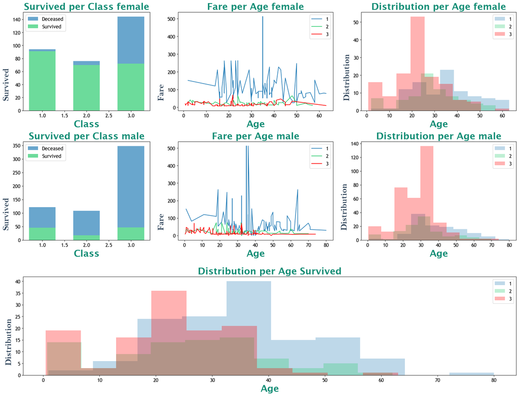

```python
fig = plt.figure(figsize=(10,10), dpi=100)

colormap = ['#2980b9', '#2ecc71', 'red']
BarKwargs = dict(width = 0.6, alpha=0.7)

for possize, possize2, sex in [[[0, 0.6, 0.45, 0.35], [0.55, 0.6, 0.55, 0.35], 'female'],
                    [[0, 0.14, 0.45, 0.35], [0.55, 0.14, 0.55, 0.35], 'male']]:
    SurPerClassBar(possize,
                   Sex=sex,
                   CMap=colormap,
                   xLabel="Class",
                   yLabel="Survived")
    AgeVSFarePerClassLine(possize2,
                          Sex=sex,
                          CMap=colormap,
                          xLabel="Age",
                          yLabel="Fare"
                         )

for possize, attribute, value in [[[1.2, 0.6, 0.55, 0.35], "Sex", "female"],
                                  [[1.2, 0.14, 0.55, 0.35], "Sex", "male"],
                                  [[0, -0.34, 1.75, 0.35], "Survived", 1]]:
    NAttributeOverAgeHist(possize,
                          Attribute=attribute,
                          Value=value,
                          CMap=colormap,
                          xLabel="Age",
                          yLabel="Distribution",
                          alpha=0.3)
```

# Vergeet niet de stijl:

```python
plt.rcParams["font.family"] = "Trebuchet MS"
plt.rcParams["font.size"] = 13
titlefont = dict(fontname = 'Lucida Sans',
         weight = 'bold',
         size   = 24,
         color = '#138d75')
labelfont = dict(fontname = 'Bell MT',
         weight = 'bold',
         size   = 22,
         color = '#34495e',
         position = (0.1,0.1),
         ha = "left")
```

# Actie:

Kijk naar de herhaaldelijke declaratie van de beschrijvingsfuncties:

- legend,
- xlabel,
- ylabel
- enz.

  Schrijf een hulpfuntie die aan het eind **in** de drie hulpfuncties aangeroepen kan worden.

```python
plt.rcParams["font.family"] = "Trebuchet MS"
plt.rcParams["font.size"] = 13
titlefont = dict(fontname = 'Lucida Sans',
         weight = 'bold',
         size   = 24,
         color = '#138d75')
labelfont = dict(fontname = 'Bell MT',
         weight = 'bold',
         size   = 22,
         color = '#34495e',
         position = (0.1,0.1),
         ha = "left")
```

# Samenvatting

Matplotlib is een stevige, bruikbare standaardbibliotheek.  
Is motor onder andere paketten, zoals Seaborn.

Prima bruikbaar voor snelle visualisaties.  
OOP framework is handig ter controle van vormgeving.

met: plt.figure()  
plt.plot() & pie, boxplot, scatter, hist en meer.

Allright...

Time for some  
beautifull seaborn action

```python
TVis.info()
```

```
<class 'pandas.core.frame.DataFrame'>
Int64Index: 891 entries, 0 to 890
Data columns (total 23 columns):
Unnamed: 0       891 non-null int64
Age              714 non-null float64
Cabin            204 non-null object
Embarked         889 non-null object
Fare             891 non-null float64
Name             891 non-null object
Parch            891 non-null int64
PassengerId      891 non-null int64
Pclass           891 non-null int64
Sex              891 non-null object
SibSp            891 non-null int64
Survived         891 non-null float64
Ticket           891 non-null object
Title            891 non-null object
Age_mean         891 non-null float64
Fare_fill        891 non-null float64
Embarked_fill    891 non-null object
Age_fill         891 non-null float64
Cabin_fill       891 non-null object
FamilySize       891 non-null int64
Family_Single    891 non-null int64
Family_Small     891 non-null int64
Family_Large     891 non-null int64
dtypes: float64(6), int64(9), object(8)
memory usage: 207.1+ KB
```

```
(177, 714)
```

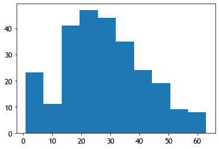

```python
plt.hist(TVis.loc[(TVis['Sex']=='female'), 'Age'])

len(TVis.loc[(TVis['Age'].isnull()), 'Age']), len(TVis.loc[(TVis['Age'].notnull()), 'Age'])
```

```
 [Text(-0.5894094953465411, -0.928760704807937, '1'),
 [Text(-0.3214960883708406, -0.5065967480770565, '32.0%'),
```

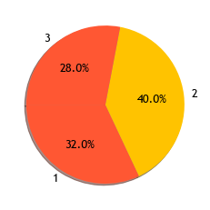

```python
nunique_cats = np.unique(cat, return_counts=True)[1]

colors = ['#FF5733', '#FFC300']
labels = np.unique(cat, return_counts=False)

plt.pie(nunique_cats, labels=labels,
autopct='%1.1f%%', shadow=True, startangle=180, colors = colors, )
```

```python
import os
```

```python
os.system('jupyter nbconvert --to html 2 Matplotlib_Docenten.ipynb')
```

```
-1
```